# Máster Universitario en Ciencia de Datos

# FIFA Analytics

Rodrigo Rico

Roger Cervantes

```r
# Cargamos las librerías necesarias:
library(dplyr)
library(kableExtra)
library(GGally)
library(grid)
library(corrplot)
library(stringr)
library(gridExtra)
library(ggplot2)
library(DMwR)
library(caret)
library(ResourceSelection)
library(pROC)
library(magrittr)
library(maps)
library(plotly)
library(DT)
library(factoextra)
library(tidyr)
library(tibble)
library(fitdistrplus)
library(FactoMineR)
library(scatterplot3d)
```

```r
# Creamos una serie de funciones para mejorar la visualización
my.head <- function(x, num=6){
  head(x, num) %>%
    kable() %>%
    kable_styling(bootstrap_options = c("striped", "condensed", "hover")) %>%
    scroll_box(width="100%",height="264px") # 72 + 32*rows
}

my.kable <- function(x){
  x %>%
    kable() %>%
    kable_styling(bootstrap_options = c("striped", "condensed", "hover")) %>%
    scroll_box(width="100%",height="264px") # 72 + 32*rows
}

my.summary <- function(x){
  summary(x) %>%
    kable() %>%
    kable_styling(bootstrap_options = c("striped", "condensed", "hover")) %>%
    scroll_box(width="100%",height=72 + 32*7)
}
```

# 1 Lectura del fichero

```r
# Leemos los jugadores
fifa <- read.csv("Data/players_20.csv", sep=",", header=TRUE, encoding = "UTF-8")

# Hacemos una primera visualización
my.head(fifa)
```

| sofifa_id | player_url | short_name | long_name | age | dob | height_cm | weight_kg | nationality | club | overall | potential | value_eur | wage_eur | player_positions | preferred_foot | international_reputation | weak_foot | skill_moves | work_rate | body_type | real_face | release_clause_eur | player_tags | team_position | team_jersey_number | loaned_from | joined | contract_valid_until | nation_position | … |
| --- | --- | --- | --- | --- | --- | --- | --- | --- | --- | --- | --- | --- | --- | --- | --- | --- | --- | --- | --- | --- | --- | --- | --- | --- | --- | --- | --- | --- | --- | --- |
| 158023 | https://sofifa.com/player/158023/lionel-messi/20/159586 | L. Messi | Lionel Andrés Messi Cuccittini | 32 | 1987-06-24 | 170 | 72 | Argentina | FC Barcelona | 94 | 94 | 95500000 | 565000 | RW, CF, ST | Left | 5 | 4 | 4 | Medium/Low | Messi | Yes | 195800000 | #Dribbler, #Distance Shooter, #Crosser, #FK Specialist, #Acrobat, #Clinical Finisher, #Complete Forward | RW | 10 |  | 2004-07-01 | 2021 |  | … |
| 20801 | https://sofifa.com/player/20801/c-ronaldo-dos-santos-aveiro/20/159586 | Cristiano Ronaldo | Cristiano Ronaldo dos Santos Aveiro | 34 | 1985-02-05 | 187 | 83 | Portugal | Juventus | 93 | 93 | 58500000 | 405000 | ST, LW | Right | 5 | 4 | 5 | High/Low | C. Ronaldo | Yes | 96500000 | #Speedster, #Dribbler, #Distance Shooter, #Acrobat, #Clinical Finisher, #Complete Forward | LW | 7 |  | 2018-07-10 | 2022 | LS | … |
| 190871 | https://sofifa.com/player/190871/neymar-da-silva-santos-jr/20/159586 | Neymar Jr | Neymar da Silva Santos Junior | 27 | 1992-02-05 | 175 | 68 | Brazil | Paris Saint-Germain | 92 | 92 | 105500000 | 290000 | LW, CAM | Right | 5 | 5 | 5 | High/Medium | Neymar | Yes | 195200000 | #Speedster, #Dribbler, #Playmaker , #Crosser, #FK Specialist, #Acrobat, #Clinical Finisher, #Complete Midfielder, #Complete Forward | CAM | 10 |  | 2017-08-03 | 2022 | LW | … |
| 200389 | https://sofifa.com/player/200389/jan-oblak/20/159586 | J. Oblak | Jan Oblak | 26 | 1993-01-07 | 188 | 87 | Slovenia | Atlético Madrid | 91 | 93 | 77500000 | 125000 | GK | Right | 3 | 3 | 1 | Medium/Medium | Normal | Yes | 164700000 |  | GK | 13 |  | 2014-07-16 | 2023 | GK | … |
| 183277 | https://sofifa.com/player/183277/eden-hazard/20/159586 | E. Hazard | Eden Hazard | 28 | 1991-01-07 | 175 | 74 | Belgium | Real Madrid | 91 | 91 | 90000000 | 470000 | LW, CF | Right | 4 | 4 | 4 | High/Medium | Normal | Yes | 184500000 | #Speedster, #Dribbler, #Acrobat | LW | 7 |  | 2019-07-01 | 2024 | LF | … |
| 192985 | https://sofifa.com/player/192985/kevin-de-bruyne/20/159586 | K. De Bruyne | Kevin De Bruyne | 28 | 1991-06-28 | 181 | 70 | Belgium | Manchester City | 91 | 91 | 90000000 | 370000 | CAM, CM | Right | 4 | 5 | 4 | High/High | Normal | Yes | 166500000 | #Dribbler, #Playmaker , #Engine, #Distance Shooter, #Crosser, #Complete Midfielder | RCM | 17 |  | 2015-08-30 | 2023 | RCM | … |

```r
# Analizamos la estructura de las variables
str(fifa)
```

```
## 'data.frame':    18278 obs. of  104 variables:
##  $ sofifa_id                 : int  158023 20801 190871 200389 183277 192985 192448 203376 177003 209331 ...
##  $ player_url                : Factor w/ 18278 levels "https://sofifa.com/player/101317/michael-ratajczak/20/159586",..: 397 5124 2497 3676 1537 2765 2674 4267 1088 5356 ...
##  $ short_name                : Factor w/ 17354 levels "�. Blanaru","�. Fara",..: 9773 3210 12708 7904 4505 8745 11813 16600 9783 11649 ...
##  $ long_name                 : Factor w/ 18218 levels "Ștefan Blanaru",..: 10955 4343 13608 8480 5494 10304 11733 17678 11387 13200 ...
##  $ age                       : int  32 34 27 26 28 28 27 27 33 27 ...
##  $ dob                       : Factor w/ 6142 levels "1977-01-21","1977-07-01",..: 1175 540 2713 3040 2334 2500 2797 2508 676 2842 ...
##  $ height_cm                 : int  170 187 175 188 175 181 187 193 172 175 ...
##  $ weight_kg                 : int  72 83 68 87 74 70 85 92 66 71 ...
##  $ nationality               : Factor w/ 162 levels "Afghanistan",..: 6 122 19 135 13 13 58 109 35 44 ...
##  $ club                      : Factor w/ 698 levels " SSV Jahn Regensburg",..: 228 353 463 64 507 401 228 389 507 389 ...
##  $ overall                   : int  94 93 92 91 91 91 90 90 90 90 ...
##  $ potential                 : int  94 93 92 93 91 91 93 91 90 90 ...
##  $ value_eur                 : int  95500000 58500000 105500000 77500000 90000000 90000000 67500000 78000000 45000000 80500000 ...
##  $ wage_eur                  : int  565000 405000 290000 125000 470000 370000 250000 200000 340000 240000 ...
```

[output cut: 86 more lines]

## 1.1 Selección de registros

```r
# Leemos los equipos
teams <- read.csv("Data/Fifa_Teams.csv", sep=";", header=TRUE)

# Hacemos una primera visualización
my.head(teams)
```

club

league

country

1. FC Nürnberg

Bundesliga

Germany

1. FSV Mainz 05

Bundesliga

Germany

Bayer 04 Leverkusen

Bundesliga

Germany

FC Bayern München

Bundesliga

Germany

Borussia Dortmund

Bundesliga

Germany

Borussia Mönchengladbach

Bundesliga

Germany

```r
# Analizamos la estructura de las variables
str(teams)
```

```
## 'data.frame':    152 obs. of  3 variables:
##  $ club   : Factor w/ 152 levels "1. FC Nürnberg",..: 1 2 18 51 23 24 44 49 57 62 ...
##  $ league : Factor w/ 8 levels "Bundesliga","Eredivisie",..: 1 1 1 1 1 1 1 1 1 1 ...
##  $ country: Factor w/ 8 levels "England","France",..: 3 3 3 3 3 3 3 3 3 3 ...
```

```r
# Juntamos los equipos con su liga
fifa <- merge(x=fifa,y=teams,by="club",all.x = TRUE)

# Mostramos las ligas seleccionadas
fifa %>%
  count(country, league, club) %>%
  count(country, league) %>%
  my.kable()
```

| country | league | n |
| --- | --- | --- |
| England | Premier League | 20 |
| France | Ligue 1 | 20 |
| Germany | Bundesliga | 18 |
| Italy | Serie A | 20 |
| Netherlands | Eredivisie | 15 |
| Portugal | Liga Nos | 15 |
| Spain | La Liga | 20 |
| Turkey | Süper Lig | 12 |
| NA | NA | 558 |

```r
# Nos quedamos solo con los registros de las ligas cargadas
fifa %<>% filter(!is.na(league))

# Miramos los registros de cada liga
table(fifa$league)
```

```
##
##     Bundesliga     Eredivisie        La Liga       Liga Nos        Ligue 1
##            554            401            624            428            577
## Premier League        Serie A      Süper Lig
##            651            606            328
```

## 1.2 Añadimos Variables

### 1.2.1 value_eur.log

```r
fifa$value_eur.log <- log(fifa$value_eur)
```

### 1.2.2 player_positions class

```r
# Creamos las variables por zona
line_defense <- c("CB", "RB", "LB", "LWB", "RWB", "LCB", "RCB")
line_midfielder <- c("CM", "CDM","CAM","LM","RM", "LAM", "RAM", "LCM", "RCM", "LDM", "RDM")
line_forward <- c("ST", "LW", "RW", "LF", "RF", "RS","LS", "CF")
line_limpiar <- c("RES", "SUB")

# Cargamos el array de posiciones de cada jugador
tmp <- fifa$player_positions
tmp <- str_split(tmp, ', ', simplify = TRUE)
tmp <- data.frame(tmp)
# Añadimos la posicion en la que juega en su equipo y en la seleccion
tmp <- data.frame(tmp, team=fifa$team_position, nation=fifa$nation_position)

# Cambiamos las distintas posiciones, por los grupos
# Limpiando (RES -> Reservas, SUB -> Suplentes) que no nos sirve
for (i in seq_along(tmp)) {
  tmp[,i] <- sapply(as.vector(tmp[[i]]), function(x) if(x %in% line_defense) "Defender" else x )
  tmp[,i] <- sapply(as.vector(tmp[[i]]), function(x) if(x %in% line_midfielder) "Midfielder" else x )
  tmp[,i] <- sapply(as.vector(tmp[[i]]), function(x) if(x %in% line_forward) "Forward" else x )
  tmp[,i] <- sapply(as.vector(tmp[[i]]), function(x) if(x %in% line_limpiar) "" else x )
}

# Miramos cuantos valores hay de cada
tmp$line_GoalKeeper <- ifelse(tmp$X1 == "GK", 1, 0) + ifelse(tmp$X2 == "GK", 1, 0) + ifelse(tmp$X3 == "GK", 1, 0)
tmp$line_Defense <- ifelse(tmp$X1 == "Defender", 1, 0) + ifelse(tmp$X2 == "Defender", 1, 0) + ifelse(tmp$X3 == "Defender", 1, 0)
tmp$line_Midfielder <- ifelse(tmp$X1 == "Midfielder", 1, 0) + ifelse(tmp$X2 == "Midfielder", 1, 0) + ifelse(tmp$X3 == "Midfielder", 1, 0)
tmp$line_Forward <- ifelse(tmp$X1 == "Forward", 1, 0) + ifelse(tmp$X2 == "Forward", 1, 0) + ifelse(tmp$X3 == "Forward", 1, 0)
tmp$player_positions.cod <- paste(tmp$line_GoalKeeper, tmp$line_Defense, tmp$line_Midfielder, tmp$line_Forward, sep = "")

# Buscamos el valor mas alto entre todas las posiciones
tmp$max <- pmax(tmp$line_GoalKeeper, tmp$line_Defense, tmp$line_Midfielder, tmp$line_Forward)
# Miramos cuantas veces aparece ese valor
tmp$num_max <- ifelse(tmp$line_GoalKeeper == tmp$max, 1, 0) + ifelse(tmp$line_Defense == tmp$max, 1, 0) + ifelse(tmp$line_Midfielder == tmp$max, 1, 0) + ifelse(tmp$line_Forward == tmp$max, 1, 0)

my.head(tmp, 20)
```

| X1 | X2 | X3 | team | nation | line_GoalKeeper | line_Defense | line_Midfielder | line_Forward | player_positions.cod | max | num_max |
| --- | --- | --- | --- | --- | --- | --- | --- | --- | --- | --- | --- |
| Midfielder | Defender | Midfielder |  |  | 0 | 1 | 2 | 0 | 0120 | 2 | 1 |
| Forward | Midfielder |  |  |  | 0 | 0 | 1 | 1 | 0011 | 1 | 2 |
| Defender |  |  |  |  | 0 | 1 | 0 | 0 | 0100 | 1 | 1 |
| Forward |  |  |  |  | 0 | 0 | 0 | 1 | 0001 | 1 | 1 |
| Forward | Forward |  |  |  | 0 | 0 | 0 | 2 | 0002 | 2 | 1 |
| Forward |  |  |  |  | 0 | 0 | 0 | 1 | 0001 | 1 | 1 |
| Forward | Forward | Forward |  |  | 0 | 0 | 0 | 3 | 0003 | 3 | 1 |
| Forward | Midfielder | Midfielder |  |  | 0 | 0 | 2 | 1 | 0021 | 2 | 1 |
| Defender |  |  |  |  | 0 | 1 | 0 | 0 | 0100 | 1 | 1 |
| Defender | Midfielder |  |  |  | 0 | 1 | 1 | 0 | 0110 | 1 | 2 |
| Midfielder | Midfielder |  |  |  | 0 | 0 | 2 | 0 | 0020 | 2 | 1 |
| Midfielder | Midfielder | Midfielder | Midfielder |  | 0 | 0 | 3 | 0 | 0030 | 3 | 1 |
| Defender |  |  | Defender |  | 0 | 1 | 0 | 0 | 0100 | 1 | 1 |
| Forward |  |  | Forward |  | 0 | 0 | 0 | 1 | 0001 | 1 | 1 |
| Forward | Midfielder | Forward | Forward |  | 0 | 0 | 1 | 2 | 0012 | 2 | 1 |
| Defender |  |  | Defender |  | 0 | 1 | 0 | 0 | 0100 | 1 | 1 |
| Defender | Midfielder |  |  |  | 0 | 1 | 1 | 0 | 0110 | 1 | 2 |
| Midfielder | Defender | Midfielder | Midfielder |  | 0 | 1 | 2 | 0 | 0120 | 2 | 1 |
| Midfielder | Defender |  |  |  | 0 | 1 | 1 | 0 | 0110 | 1 | 2 |
| GK |  |  |  |  | 1 | 0 | 0 | 0 | 1000 | 1 | 1 |

```r
tmp$player_positions.class <- ""
tmp$player_positions.class <- ifelse(tmp$num_max==1 & tmp$line_GoalKeeper==tmp$max, "GK", tmp$player_positions.class)
tmp$player_positions.class <- ifelse(tmp$num_max==1 & tmp$line_Defense==tmp$max, "Defender", tmp$player_positions.class)
tmp$player_positions.class <- ifelse(tmp$num_max==1 & tmp$line_Midfielder==tmp$max, "Midfielder", tmp$player_positions.class)
tmp$player_positions.class <- ifelse(tmp$num_max==1 & tmp$line_Forward==tmp$max, "Forward", tmp$player_positions.class)

table(tmp$player_positions.class)
```

```
##
##              Defender    Forward         GK Midfielder
##        415       1209        738        459       1348
```

```r
# En caso de que no tengamos una posición mas usada que otras, cogemos
# La posición en la que juega en su equipo
# La posición en la que juega en su equipo
# La primera posición que veiene marcada
tmp$player_positions.class <- ifelse(tmp$player_positions.class=="", tmp$team, tmp$player_positions.class)
tmp$player_positions.class <- ifelse(tmp$player_positions.class=="", tmp$nation, tmp$player_positions.class)
tmp$player_positions.class <- ifelse(tmp$player_positions.class=="", tmp$X1, tmp$player_positions.class)

# Tabla final de posiciones
table(tmp$player_positions.class)
```

```
##
##   Defender    Forward         GK Midfielder
##       1339        850        459       1521
```

```r
# Lo pasamos al dataframe original
fifa$player_positions.cod <- tmp$player_positions.cod
fifa$player_positions.class <- tmp$player_positions.class
```

# 2 Limpieza

## 2.1 Valores Perdidos

```r
# Dividimos el dataset entre porteros y jugadores de campo
fifa.gk  <- fifa %>% filter(player_positions.class == "GK")
fifa.campo  <- fifa %>% filter(player_positions.class != "GK")

# En cada caso, quitamos las 6 caracteristicas que solo estan informados en el otro grupo
fifa.gk <- fifa.gk[, !names(fifa.gk) %in% c("pace","shooting","passing","dribbling","defending","physic")]
fifa.campo <- fifa.campo[, !names(fifa.campo) %in% c("gk_diving","gk_handling","gk_kicking","gk_reflexes","gk_speed","gk_positioning")]

# Quitamos las valoraciones en la posicion para el grupo de porteros
fifa.gk <- fifa.gk[, !names(fifa.gk) %in% c("ls","st","rs","lw","lf","cf","rf","rw","lam","cam","ram","lm","lcm","cm","rcm","rm","lwb","ldm","cdm","rdm","rwb","lb","lcb","cb","rcb","rb")]

# Miramos que variables tienen valores perdidos
list <- colSums(is.na(fifa.gk)); sort(list[list != 0], decreasing = TRUE)
```

```
## nation_jersey_number   release_clause_eur
##                  405                   17
```

```r
list <- colSums(fifa.gk==""); sort(list[list != 0], decreasing = TRUE)
```

```
##     player_tags     loaned_from nation_position   player_traits          joined
##             459             442             405             257              17
```

```r
list <- colSums(fifa.gk==0); sort(list[list != 0], decreasing = TRUE)
```

```
## named numeric(0)
```

```r
list <- colSums(is.na(fifa.campo)); sort(list[list != 0], decreasing = TRUE)
```

```
## nation_jersey_number   release_clause_eur
##                 3295                  190
```

```r
list <- colSums(fifa.campo==""); sort(list[list != 0], decreasing = TRUE)
```

```
##     loaned_from nation_position     player_tags   player_traits          joined
##            3522            3295            3162            1675             188
```

```r
list <- colSums(fifa.campo==0); sort(list[list != 0], decreasing = TRUE)
```

```
## value_eur
##         2
```

```r
# Eliminamos los datos que tengan vacíos alguno de los dos campos objetivo
fifa <- fifa %>% filter(value_eur != 0)
```

Vemos que tanto para porteros como jugadores de campo, las únicas variables que tienen null son nation_jersey_number y release_clause_eur que no se usan en el modelo. Las variables que están en blanco son: player_tags, loaned_from, nation_position, player_traits, joined que tampoco se usan. Y solo hay dos registros con value_eur = 0. Estos registros si que pueden interferir en el estudio y por eso los eliminamos.

## 2.2 Valores Extremos

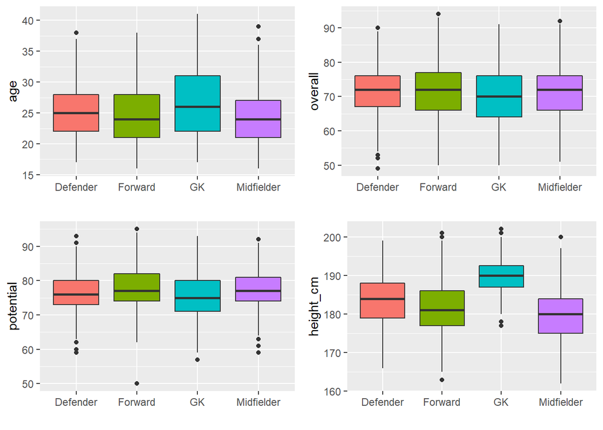

```r
gp1<- ggplot(fifa, aes(x=player_positions.class, y=age,       fill=player_positions.class)) + geom_boxplot() + theme(legend.position="none") + xlab("")
gp2<- ggplot(fifa, aes(x=player_positions.class, y=overall,   fill=player_positions.class)) + geom_boxplot() + theme(legend.position="none") + xlab("")
gp3<- ggplot(fifa, aes(x=player_positions.class, y=potential, fill=player_positions.class)) + geom_boxplot() + theme(legend.position="none") + xlab("")
gp4<- ggplot(fifa, aes(x=player_positions.class, y=height_cm, fill=player_positions.class)) + geom_boxplot() + theme(legend.position="none") + xlab("")
gp5<- ggplot(fifa, aes(x=player_positions.class, y=weight_kg, fill=player_positions.class)) + geom_boxplot() + theme(legend.position="none") + xlab("")
gp6<- ggplot(fifa, aes(x=player_positions.class, y=value_eur, fill=player_positions.class)) + geom_boxplot() + theme(legend.position="none") + xlab("")
gp7<- ggplot(fifa, aes(x=player_positions.class, y=wage_eur,  fill=player_positions.class)) + geom_boxplot() + theme(legend.position="none") + xlab("")

grid.arrange(gp1, gp2, gp3, gp4, ncol = 2)
```

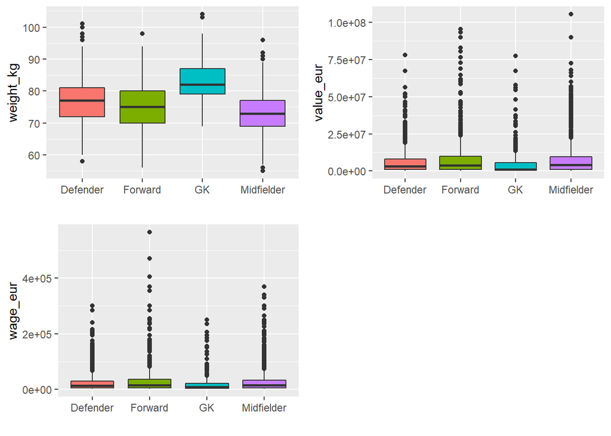

```r
grid.arrange(gp5, gp6, gp7, ncol = 2)
```

## 2.3 Valores estadísticos

Las variables que albergan las métricas que definen el rendimiento del jugador en el juego están acompañadas por un valor fijo y una cantidad variable que se suma a éste, para representar la evolución del jugador durante algunos modos de juego. Para este análisis nos quedaremos con la parte fija.

```r
# Pasamos las métricas de rendimiento nuevas a numéricas
for(i in 45:104) { # Iteramos sobre las métricas que queremos limpiar
  fifa[,i] <- as.numeric(substr(fifa[,i], 1, 2)) # Cogemos los dos primeros caracteres y convertimos a numeric

  # Calculamos las medias de la variable actual por player_positions.class
  media.ByClass <- aggregate(fifa[,i]~player_positions.class, fifa, median)

  # Por cada registro actualizamos las variables NA de esta class por la media calculada
  for (row in 1:nrow(media.ByClass)){
    fifa[fifa$player_positions.class==media.ByClass[row, "player_positions.class"] & is.na(fifa[,i]), i] <- as.numeric(media.ByClass[row, "fifa[, i]"])
  }
  # En caso de no encontrar valores para su grupo, ponemos la media de la variable
  fifa[is.na(fifa[,i]), i] <- as.numeric(mean(fifa[,i], na.rm = TRUE))
}
```

## 2.4 Exportación de los datos preprocesados

Una vez limpiado nuestro conjunto de datos, guardamos el resultado en un nuevo fichero llamado fifa_2020_clean.csv:

```r
# Exportación de los datos limpios en .csv
write.csv(fifa, "Data/fifa_2020_clean.csv")
```

# 3 Análisis exploratorio de los datos (EDA)

Definimos esta función que se usará para representar varias gráficas en la misma celda con la librería `ggplot2`.

```r
# Multiple plot function
#
# ggplot objects can be passed in ..., or to plotlist (as a list of ggplot objects)
# - cols:   Number of columns in layout
# - layout: A matrix specifying the layout. If present, 'cols' is ignored.
#
# If the layout is something like matrix(c(1,2,3,3), nrow=2, byrow=TRUE),
# then plot 1 will go in the upper left, 2 will go in the upper right, and
# 3 will go all the way across the bottom.
#
multiplot <- function(..., plotlist=NULL, file, cols=1, layout=NULL) {

  # Make a list from the ... arguments and plotlist
  plots <- c(list(...), plotlist)

  numPlots = length(plots)

  # If layout is NULL, then use 'cols' to determine layout
  if (is.null(layout)) {
    # Make the panel
    # ncol: Number of columns of plots
    # nrow: Number of rows needed, calculated from # of cols
    layout <- matrix(seq(1, cols * ceiling(numPlots/cols)),
                    ncol = cols, nrow = ceiling(numPlots/cols))
  }

 if (numPlots==1) {
    print(plots[[1]])

  } else {
    # Set up the page
    grid.newpage()
    pushViewport(viewport(layout = grid.layout(nrow(layout), ncol(layout))))

    # Make each plot, in the correct location
    for (i in 1:numPlots) {
      # Get the i,j matrix positions of the regions that contain this subplot
      matchidx <- as.data.frame(which(layout == i, arr.ind = TRUE))

      print(plots[[i]], vp = viewport(layout.pos.row = matchidx$row,
                                      layout.pos.col = matchidx$col))
    }
  }
}
```

## 3.1 Datos de partida

Los datos de partida en el EDA se encuentran en el *dataset* `fifa` resultado del proceso previo de limpieza.

```r
# Visualizamos los datos de partida para el EDA
my.head(fifa, 10)
```

sofifa_id

player_url

short_name

long_name

age

dob

height_cm

weight_kg

nationality

overall

potential

value_eur

wage_eur

player_positions

preferred_foot

international_reputation

weak_foot

skill_moves

work_rate

body_type

real_face

release_clause_eur

player_tags

team_position

team_jersey_number

loaned_from

joined

contract_valid_until

nation_position

nation_jersey_number

pace

shooting

passing

dribbling

defending

physic

gk_diving

gk_handling

gk_kicking

gk_reflexes

gk_speed

gk_positioning

player_traits

attacking_crossing

attacking_finishing

attacking_heading_accuracy

attacking_short_passing

attacking_volleys

skill_dribbling

skill_curve

skill_fk_accuracy

skill_long_passing

skill_ball_control

movement_acceleration

movement_sprint_speed

movement_agility

movement_reactions

movement_balance

power_shot_power

power_jumping

power_stamina

power_strength

power_long_shots

mentality_aggression

mentality_interceptions

mentality_positioning

mentality_vision

mentality_penalties

mentality_composure

defending_marking

defending_standing_tackle

defending_sliding_tackle

goalkeeping_diving

goalkeeping_handling

goalkeeping_kicking

goalkeeping_positioning

goalkeeping_reflexes

ls

st

rs

lw

lf

cf

rf

rw

lam

cam

ram

lm

lcm

cm

rcm

rm

lwb

ldm

cdm

rdm

rwb

lb

lcb

cb

rcb

rb

league

country

value_eur.log

player_positions.cod

player_positions.class

1. FC Nürnberg

231110

https://sofifa.com/player/231110/patrick-erras/20/159586

P. Erras

Patrick Erras

24

1995-01-21

196

85

Germany

70

75

2200000

7000

CDM, CB, CM

Right

1

3

2

Medium/High

Lean

Yes

3600000

SUB

29

2015-09-13

2020

NA

35

42

60

46

69

72

NA

NA

NA

NA

NA

NA

Power Free-Kick

44

40

57

73

18

38

24

32

66

62

33

37

31

72

29

49

34

67

81

47

63

69

43

67

31

75

72

72

59

13

9

11

8

12

50

50

50

49

51

51

51

49

55

55

55

52

63

63

63

52

60

68

68

68

60

61

66

66

66

61

Bundesliga

Germany

14.60397

0120

Midfielder

1. FC Nürnberg

231624

https://sofifa.com/player/231624/fabian-schleusener/20/159586

F. Schleusener

Fabian Schleusener

27

1991-10-24

186

80

Germany

69

69

1100000

8000

ST, LM

Right

1

4

3

High/Medium

Normal

No

1800000

SUB

23

2019-07-10

2022

NA

80

67

58

66

28

69

NA

NA

NA

NA

NA

NA

63

73

57

63

65

64

57

39

49

67

76

84

68

67

66

71

68

70

75

55

51

26

68

58

54

66

29

22

20

6

9

14

7

8

68

68

68

67

67

67

67

67

64

64

64

66

58

58

58

66

51

47

47

47

51

48

42

42

42

48

Bundesliga

Germany

13.91082

0011

Forward

1. FC Nürnberg

237500

https://sofifa.com/player/237500/dennis-lippert/20/159586

D. Lippert

Dennis Lippert

23

1996-02-20

172

63

Germany

61

70

350000

2000

LB

Left

1

3

2

Medium/Medium

Lean

No

630000

RES

34

2017-01-29

2020

NA

66

31

48

60

59

48

NA

NA

NA

NA

NA

NA

62

25

42

55

23

54

49

26

36

62

68

65

75

54

79

33

76

61

35

42

56

59

37

36

28

43

60

64

59

8

10

14

15

5

43

43

43

52

47

47

47

52

49

49

49

52

49

49

49

52

59

54

54

54

59

59

55

55

55

59

Bundesliga

Germany

12.76569

0100

Defender

1. FC Nürnberg

241190

https://sofifa.com/player/241190/torles-knoll/20/159586

T. Knöll

Törles Knöll

21

1997-09-13

184

79

Germany

65

74

850000

3000

ST

Right

1

3

2

Medium/Medium

Normal

No

1500000

SUB

19

2018-07-01

2020

NA

59

64

46

61

25

59

NA

NA

NA

NA

NA

NA

32

69

64

54

54

58

47

40

39

64

55

63

65

64

66

63

66

59

68

59

33

19

68

52

52

51

20

23

17

7

12

8

12

12

63

63

63

58

61

61

61

58

59

59

59

56

52

52

52

56

41

40

40

40

41

39

38

38

38

39

Bundesliga

Germany

13.65299

0001

Forward

1. FC Nürnberg

239367

https://sofifa.com/player/239367/robin-hack/20/159586

R. Hack

Robin Hack

20

1998-08-27

176

69

Germany

65

79

1200000

3000

LW, ST

Right

1

4

4

Medium/Medium

Lean

No

2600000

SUB

17

2019-07-01

2023

NA

80

60

53

73

32

45

NA

NA

NA

NA

NA

NA

56

67

47

52

60

72

53

49

48

72

83

77

83

54

82

66

36

51

45

42

38

27

55

55

54

60

31

31

29

8

9

9

10

9

61

61

61

64

63

63

63

64

61

61

61

62

53

53

53

62

49

43

43

43

49

46

38

38

38

46

Bundesliga

Germany

13.99783

0002

Forward

1. FC Nürnberg

251224

https://sofifa.com/player/251224/paul-philipp-besong/20/159586

P. Besong

Paul-Philipp Besong

18

2000-10-06

184

78

Germany

58

77

260000

1000

ST

Right

1

3

3

Medium/Medium

Normal

No

579000

RES

27

2019-07-01

2023

NA

65

55

39

54

28

69

NA

NA

NA

NA

NA

NA

30

58

59

50

44

50

31

25

28

54

60

69

70

48

76

59

75

63

77

47

56

24

55

41

51

49

22

29

23

9

9

8

14

12

56

56

56

51

53

53

53

51

50

50

50

50

45

45

45

50

40

39

39

39

40

40

41

41

41

40

Bundesliga

Germany

12.46844

0001

Forward

1. FC Nürnberg

212248

https://sofifa.com/player/212248/felix-lohkemper/20/159586

F. Lohkemper

Felix Lohkemper

24

1995-01-26

180

76

Germany

67

74

1100000

5000

ST, LW, RW

Right

1

3

3

Medium/Medium

Normal

No

2000000

SUB

7

2019-07-01

2022

NA

83

62

54

69

29

61

NA

NA

NA

NA

NA

NA

53

63

59

64

60

70

57

40

41

68

79

86

71

63

74

68

85

67

64

53

41

27

68

52

57

56

29

24

20

13

12

15

7

13

66

66

66

66

66

66

66

66

63

63

63

65

56

56

56

65

50

45

45

45

50

47

42

42

42

47

Bundesliga

Germany

13.91082

0003

Forward

1. FC Nürnberg

203725

https://sofifa.com/player/203725/virgil-misidjan/20/159586

V. Misidjan

Virgil Misidjan

25

1993-07-24

173

70

Netherlands

72

73

3700000

12000

RW, RM, LM

Right

1

4

3

Medium/Medium

Lean

Yes

6200000

RES

24

2018-08-31

2021

NA

86

64

64

77

29

59

NA

NA

NA

NA

NA

NA

Selfish, Early Crosser

66

70

41

68

61

77

70

65

52

73

87

85

86

68

84

59

71

64

56

57

55

32

69

64

54

66

29

24

22

12

7

8

10

7

66

66

66

72

70

70

70

72

70

70

70

71

62

62

62

71

54

49

49

49

54

50

41

41

41

50

Bundesliga

Germany

15.12384

0021

Midfielder

1. FC Nürnberg

233960

https://sofifa.com/player/233960/lukas-muhl/20/159586

L. Mühl

Lukas Mühl

22

1997-01-27

189

83

Germany

72

80

4200000

9000

CB

Right

1

3

2

Medium/Medium

Normal

No

7500000

SUB

28

2016-05-07

2021

NA

74

37

60

58

69

74

NA

NA

NA

NA

NA

NA

Injury Prone, Leadership

49

25

66

73

39

53

39

22

67

66

67

79

54

69

50

59

66

65

79

45

73

66

29

59

26

65

65

75

73

14

14

11

12

10

52

52

52

55

54

54

54

55

57

57

57

58

62

62

62

58

66

69

69

69

66

67

70

70

70

67

Bundesliga

Germany

15.25060

0100

Defender

1. FC Nürnberg

208730

https://sofifa.com/player/208730/enrico-valentini/20/159586

E. Valentini

Enrico Valentini

30

1989-02-20

182

78

Germany

71

71

1900000

9000

RB, RM

Right

1

3

3

Medium/Medium

Normal

No

3000000

SUB

22

2017-07-01

2020

NA

76

59

69

71

65

74

NA

NA

NA

NA

NA

NA

Injury Prone

78

55

55

71

51

72

70

71

62

71

77

76

71

69

70

69

68

78

72

62

77

63

55

61

61

67

67

67

68

7

8

14

14

10

64

64

64

68

66

66

66

68

66

66

66

69

66

66

66

69

71

68

68

68

71

69

67

67

67

69

Bundesliga

Germany

14.45736

0110

Defender

Una vez planteados los objetivos analíticos, el primer paso del análisis exploratorio es estudiar la distribución de las variables predictoras y su dependencia con las variables a predecir. También resulta interesante observar la correlación entre variables predictoras.

## 3.2 Variables objetivo

Las variables objetivo de este análisis son:

- El valor de mercado de los jugadores en euros: `value_eur`.
- La posición de los jugadores en el terreno de juego: `player_positions.class`.

Representamos a continuación las distribuciones de ambas magnitudes:

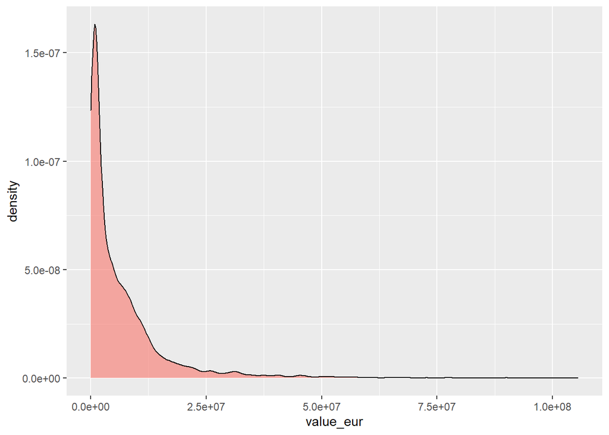

```r
ggplot(fifa, aes(x = value_eur, fill = "red")) + geom_density(alpha = 0.6) + theme(legend.position = "none")
```

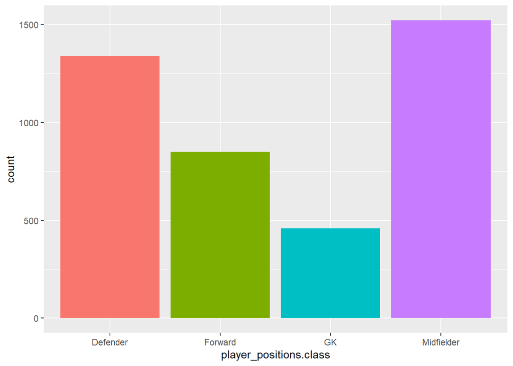

```r
ggplot(fifa, aes(x = player_positions.class, fill = player_positions.class)) + geom_bar() + theme(legend.position = "none")
```

La distribución del valor de mercado sigue una ley de distribución *Gamma* a simple vista.

```r
# En lugar de ajustar los valores en euros lo haremos en millones de euros:
x.gamma <- fifa$value_eur/10e6
fit.gamma <- fitdist(x.gamma, distr = "gamma")
summary(fit.gamma)
```

```
## Fitting of the distribution ' gamma ' by maximum likelihood
## Parameters :
##        estimate Std. Error
## shape 0.6869172 0.01279995
## rate  1.0244611 0.02703839
## Loglikelihood:  -2275.866   AIC:  4555.732   BIC:  4568.402
## Correlation matrix:
##           shape      rate
## shape 1.0000000 0.7060212
## rate  0.7060212 1.0000000
```

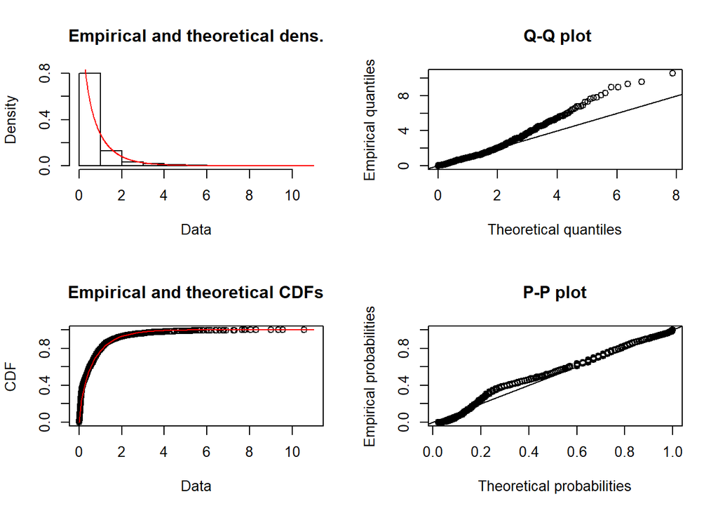

```r
plot(fit.gamma)
```

(Los resultados de los ajustes los comentaremos en el documento PDF)

Influencia de la posición del jugador en el valor de mercado:

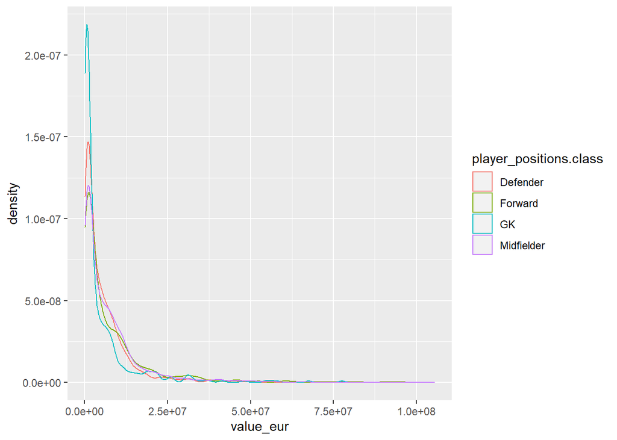

```r
ggplot(fifa, aes(x = value_eur, colour = player_positions.class)) + geom_density()
```

Parece existir una ligera influencia de la posición del jugador en valor de mercado. Si observamos la posición de los picos y la altura de la falda derecha de las distribuciones, nos daremos cuenta de que los delanteros tienden a ser más caros que los defensas.

## 3.3 Edad, peso y altura

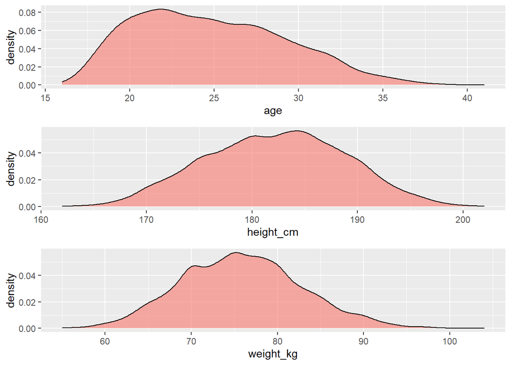

```r
h1 <- ggplot(fifa, aes(x = age, fill = "red")) + geom_density(alpha = 0.6) + theme(legend.position = "none")
h2 <- ggplot(fifa, aes(x = height_cm, fill = "red")) + geom_density(alpha = 0.6) + theme(legend.position = "none")
h3 <- ggplot(fifa, aes(x = weight_kg, fill = "red")) + geom_density(alpha = 0.6) + theme(legend.position = "none")

multiplot(h1, h2, h3, cols=1)
```

Podemos observar si existe dependencia entre estas variables y la posición del jugador:

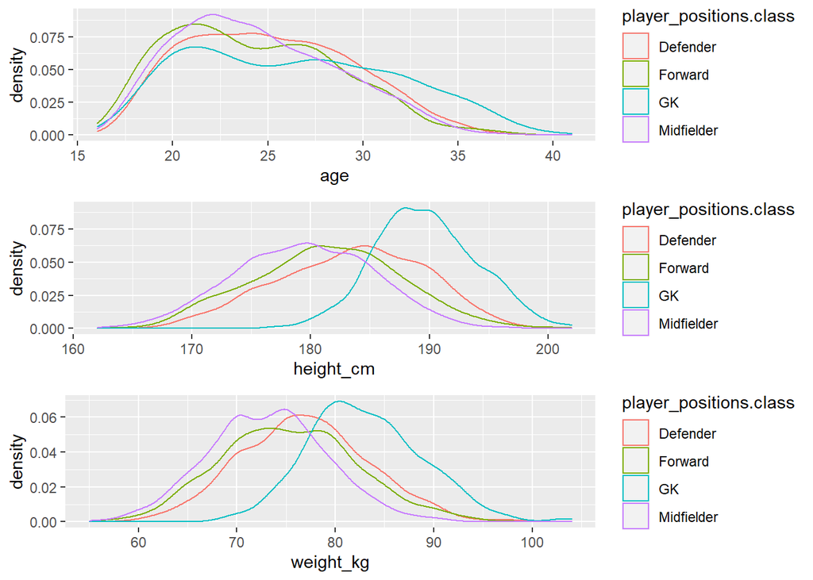

```r
h1 <- ggplot(fifa, aes(x = age, colour = player_positions.class)) + geom_density()
h2 <- ggplot(fifa, aes(x = height_cm, colour = player_positions.class)) + geom_density()
h3 <- ggplot(fifa, aes(x = weight_kg, colour = player_positions.class)) + geom_density()

multiplot(h1, h2, h3, cols=1)
```

- Edad: no se aprecian diferencias muy acuciantes entre las edades de cada grupo. Aunque existe una ligera tendencia entre los porteros a tener mayor edad.
- Altura: en caso sí se observa que los porteros son signifcativamente más altos, y que los jugadores más bajos son los mediocentros.
- Peso: los porteros son significativamente más pesados.

En general, se observan diferencias entre las distribuciones de porteros, defensas, mediocentros y delanteros. Por tanto estas variables pueden resultar útiles para el análisis de la posición óptima de los jugadores.

Ahora vamos a ver la dependencia con la otra variable objetivo: el valor de mercado `value_eur`:

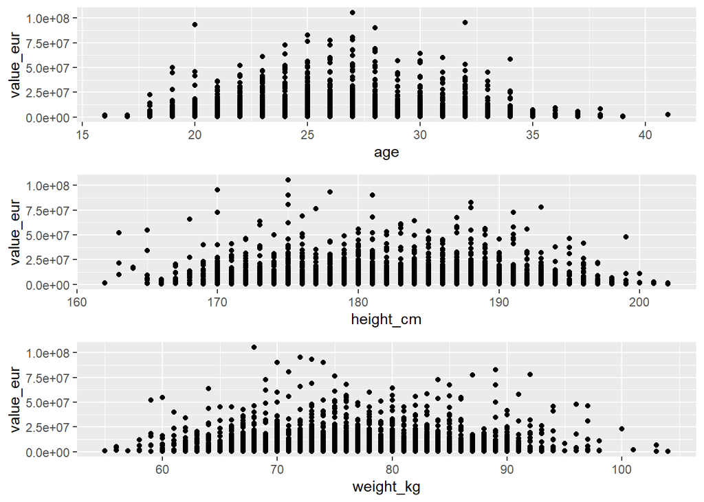

```r
h1 <- ggplot(fifa, aes(x=age, y=value_eur)) + geom_point()
h2 <- ggplot(fifa, aes(x=height_cm, y=value_eur)) + geom_point()
h3 <- ggplot(fifa, aes(x=weight_kg, y=value_eur)) + geom_point()

multiplot(h1, h2, h3, cols=1)
```

Para terminar con esta terna de variables, podemos representar la correlación entre ellas y la correlación con el valor de mercado (al ser ésta una variable numérica):

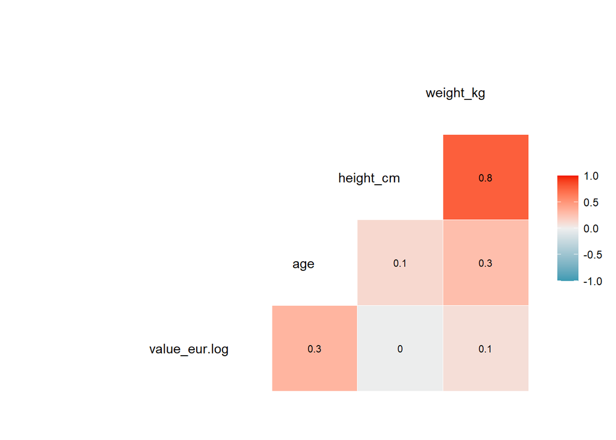

```r
val_list <- c("value_eur.log", "age", "height_cm", "weight_kg")
ggcorr(fifa[val_list], label = TRUE, label_size = 2.9, hjust = 1, layout.exp = 2)
```

Como era de esperar por los resultados gráficos obtenidos, la edad, el peso y la altura no son buenos predictores del valor de mercado, por lo tanto no se incluirán en el análisis de la predicción de éste. Algo que se esperaba es la estrecha correlación entre la altura y el peso. La altura y el peso son dos variables que pueden influir en la posición del jugador, como se ha observado en los gráficos, pero al estar tan estrechamente correlacionadas la mejor opción puede ser tomar una sola para el análisis de la posición.

## 3.4 Habilidades básicas

Las habilidades son las variables que más influencia se espera que tengan en la predicción tanto de la posición del jugador como de su valor de mercado.

En el juego un jugador está representado por 6 habilidades básicas. Que son `pace`,`shooting`, `passing`, `dribbling`, `defending` y `physical`.

[figure not shown]

player overview

Para hacer un análisis exploratorio más significativo y adaptado a nuestro objetivo, representaremos cada una de estas habilidades sobre cada una de las tres clases de posiciones: defensores (`Defender`), mediocampistas (`Midfielder`) y atacantes (`Forward`):

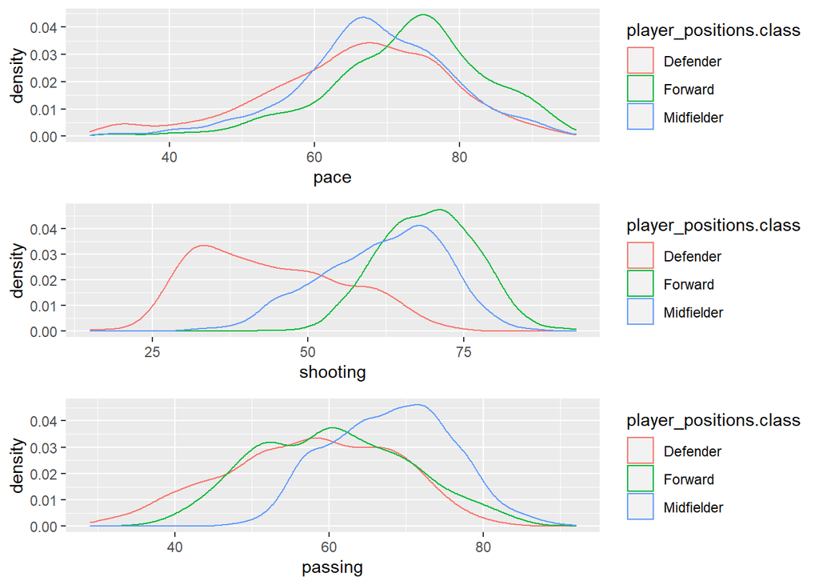

```r
library(ggplot2)

d1 <- ggplot(fifa, aes(x = pace,     colour = player_positions.class)) + geom_density()
d2 <- ggplot(fifa, aes(x = shooting, colour = player_positions.class)) + geom_density()
d3 <- ggplot(fifa, aes(x = passing,  colour = player_positions.class)) + geom_density()
d4 <- ggplot(fifa, aes(x = dribbling, colour = player_positions.class)) + geom_density()
d5 <- ggplot(fifa, aes(x = defending, colour = player_positions.class)) + geom_density()
d6 <- ggplot(fifa, aes(x = physic,    colour = player_positions.class)) + geom_density()

multiplot(d1, d2, d3, cols=1)
```

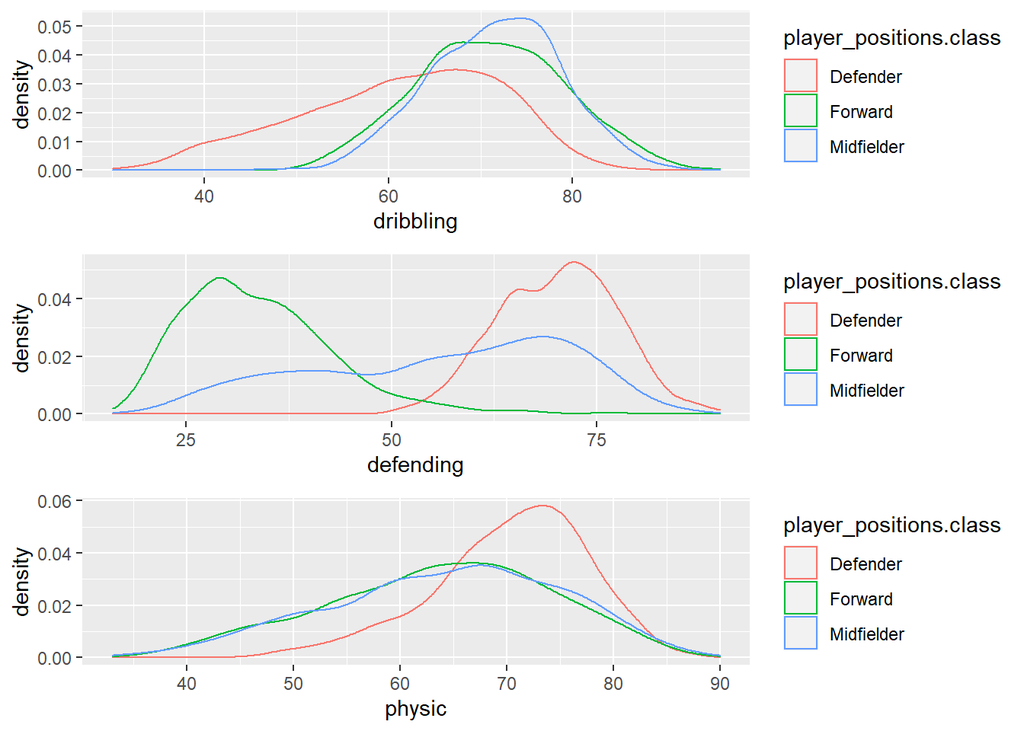

```r
multiplot(d4, d5, d6, cols=1)
```

Se puede observar la diferencia en las distribuciones entre cada una de las tres posiciones. A continuación se calcula la media de cada una de las distribuciones anteriores:

```r
pace <-      aggregate(fifa$pace~player_positions.class, fifa, mean)
shooting <-  aggregate(fifa$shooting~player_positions.class, fifa, mean)
passing <-   aggregate(fifa$passing~player_positions.class, fifa, mean)
dribbling <- aggregate(fifa$dribbling~player_positions.class, fifa, mean)
defending <- aggregate(fifa$defending~player_positions.class, fifa, mean)
physic <-    aggregate(fifa$physic~player_positions.class, fifa, mean)

means <- data.frame(pace[1], pace[2], shooting[2], passing[2], dribbling[2], defending[2], physic[2])
my.head(means)
```

| player_positions.class | fifa.pace | fifa.shooting | fifa.passing | fifa.dribbling | fifa.defending | fifa.physic |
| --- | --- | --- | --- | --- | --- | --- |
| Defender | 65.66293 | 43.83408 | 57.49701 | 61.19208 | 70.16891 | 70.37593 |
| Forward | 73.00118 | 69.23793 | 60.45230 | 71.05772 | 33.66784 | 63.65253 |
| Midfielder | 68.19987 | 61.93425 | 67.98093 | 71.57857 | 55.80999 | 64.19724 |

Y las desviaciones estándar:

```r
pace <-      aggregate(fifa$pace~player_positions.class, fifa, sd)
shooting <-  aggregate(fifa$shooting~player_positions.class, fifa, sd)
passing <-   aggregate(fifa$passing~player_positions.class, fifa, sd)
dribbling <- aggregate(fifa$dribbling~player_positions.class, fifa, sd)
defending <- aggregate(fifa$defending~player_positions.class, fifa, sd)
physic <-    aggregate(fifa$physic~player_positions.class, fifa, sd)

sdevs <- data.frame(pace[1], pace[2], shooting[2], passing[2], dribbling[2], defending[2], physic[2])
my.head(sdevs)
```

| player_positions.class | fifa.pace | fifa.shooting | fifa.passing | fifa.dribbling | fifa.defending | fifa.physic |
| --- | --- | --- | --- | --- | --- | --- |
| Defender | 12.49673 | 11.842496 | 10.865895 | 10.895219 | 7.199156 | 7.266788 |
| Forward | 10.73749 | 7.693720 | 10.021929 | 8.112430 | 9.038070 | 10.585038 |
| Midfielder | 10.54905 | 9.866725 | 7.850346 | 7.199089 | 15.570385 | 10.956818 |

En la tabla de medias podemos apreciar en forma numérica las diferencias que se visualizaban en las gráficas anteriores. Podemos concluir que las seis habilidades básicas son buenas predictoras de la posición del jugador y por tanto deben estar presentes en el modelo de clasificación.

En cuanto a la dependencia de éstas con el valor de mercado del jugador:

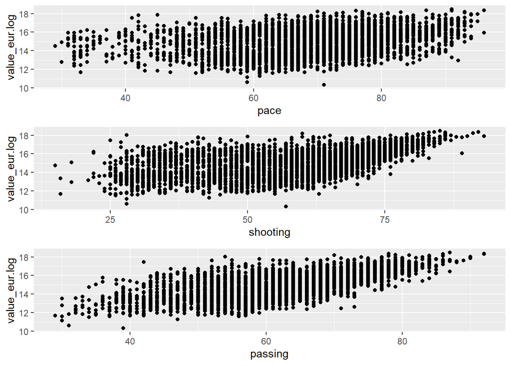

```r
h1 <- ggplot(fifa, aes(x=pace, y=value_eur.log)) + geom_point()
h2 <- ggplot(fifa, aes(x=shooting, y=value_eur.log)) + geom_point()
h3 <- ggplot(fifa, aes(x=passing, y=value_eur.log)) + geom_point()

multiplot(h1, h2, h3, cols=1)
```

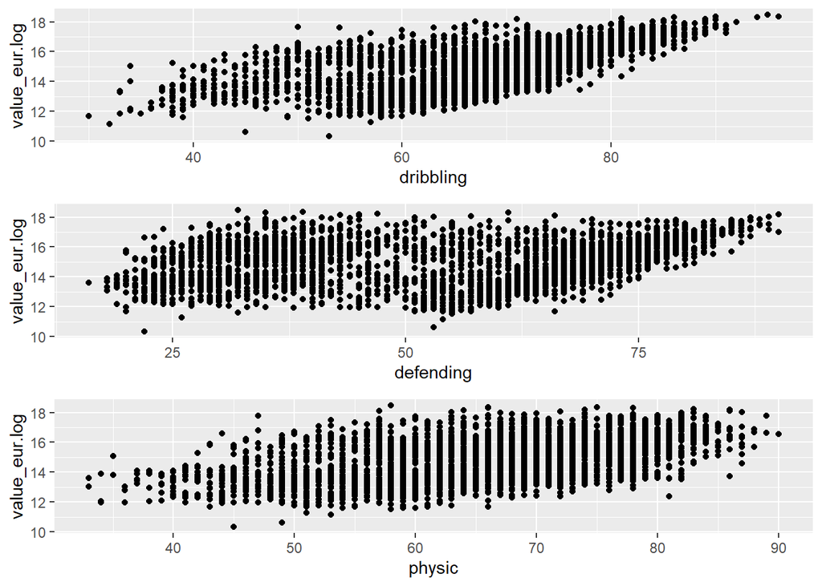

```r
h1 <- ggplot(fifa, aes(x=dribbling, y=value_eur.log)) + geom_point()
h2 <- ggplot(fifa, aes(x=defending, y=value_eur.log)) + geom_point()
h3 <- ggplot(fifa, aes(x=physic, y=value_eur.log)) + geom_point()

multiplot(h1, h2, h3, cols=1)
```

Observamos cierta relación entre cada una de las habilidades y el valor del jugador. Especialmente en las habilidades de atacante, que suelen ser los jugadores más cotizados. Sin embargo la correlación no es todo lo clara que podría esperarse, hay variables donde ni siquiera se observa relación alguna. Esto ocurre porque una habilidad por sí sola no hace a un jugador más caro o barato, si no el conjunto de ellas.

Para observar este fenómenos representaremos el `overall rating` y el `potential` en función del valor de mercado:

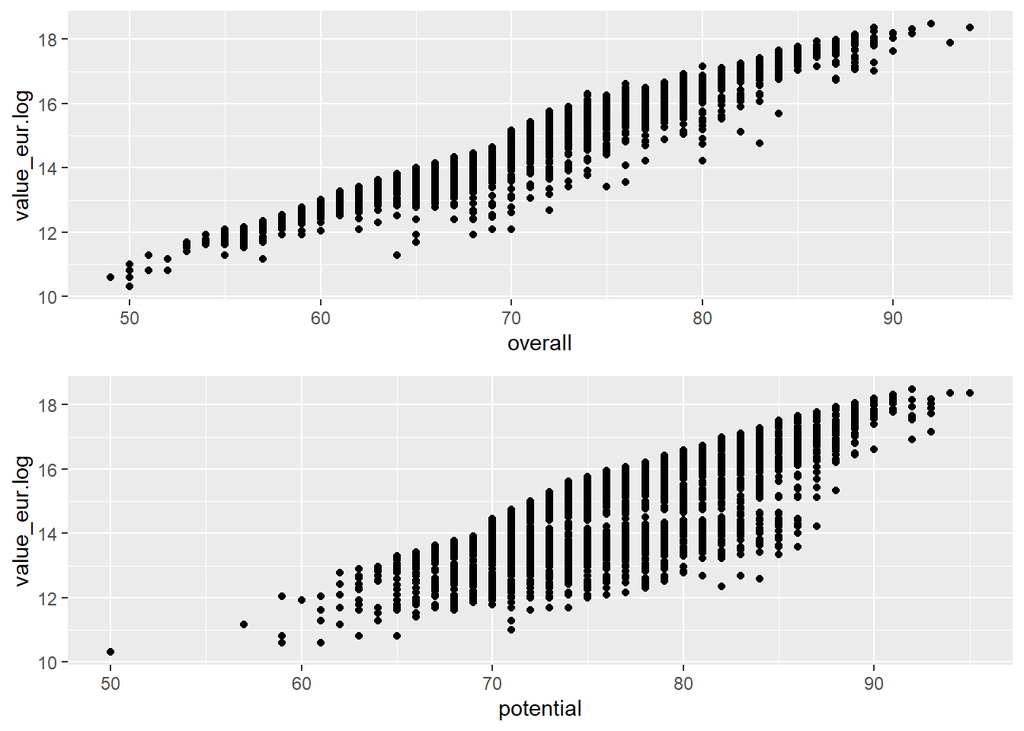

```r
h1 <- ggplot(fifa, aes(x=overall, y=value_eur.log)) + geom_point()
h2 <- ggplot(fifa, aes(x=potential, y=value_eur.log)) + geom_point()

multiplot(h1, h2, cols = 1)
```

Para cuantificar todas estas dependencias, calculamos los coeficientes de correlación entre cada una de las habilidades y el valor de mercado, incluyendo el `overall`:

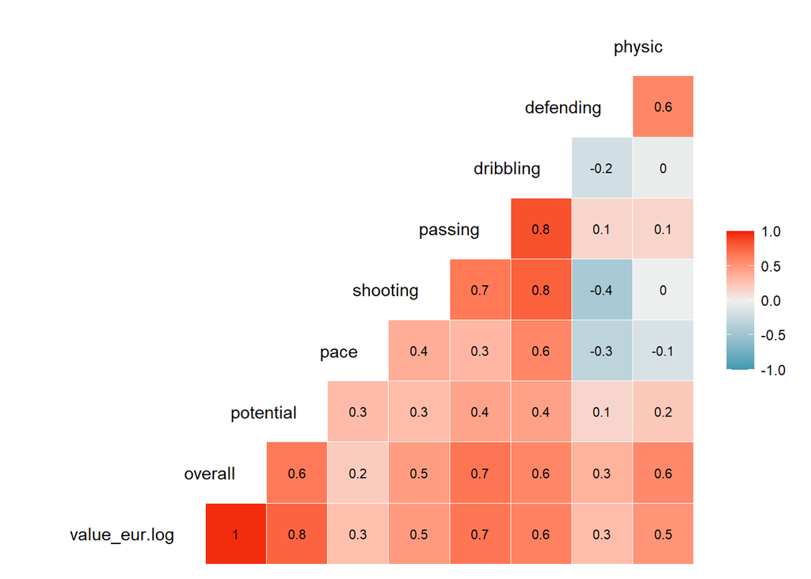

```r
val_list <- c("value_eur.log", "overall", "potential", "pace", "shooting", "passing", "dribbling", "defending", "physic")
ggcorr(fifa[val_list], label = TRUE, label_size = 2.9, hjust = 1, layout.exp = 2)
```

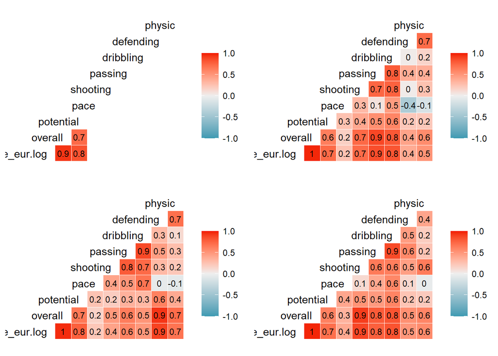

```r
#TODO: Goal Keeper
fifa.gk  <- fifa %>% filter(player_positions.class == "GK")
fifa.def <- fifa %>% filter(player_positions.class == "Defender")
fifa.mid <- fifa %>% filter(player_positions.class == "Midfielder")
fifa.for <- fifa %>% filter(player_positions.class == "Forward")

h1 <- ggcorr( fifa.gk[val_list], label = TRUE, label_size = 3, hjust = 1, layout.exp = 2)
h2 <- ggcorr(fifa.def[val_list], label = TRUE, label_size = 3, hjust = 1, layout.exp = 2)
h3 <- ggcorr(fifa.mid[val_list], label = TRUE, label_size = 3, hjust = 1, layout.exp = 2)
h4 <- ggcorr(fifa.for[val_list], label = TRUE, label_size = 3, hjust = 1, layout.exp = 2)

multiplot(h1, h2, h3, h4, cols = 2)
```

Recordamos que tenemos dos objetivos analíticos:

- Predecir el valor de mercado mediante regresión.
- Clasificar cada jugador en su posición óptima.

El valor de mercado depende de la posición (y de otras variables) pero la posición no depende del valor de mercado. Entonces a la hora de construir nuestro *pipeline*, lo correcto es colocar el clasificador en primera línea y aplicar la regresión por separado a defensas, mediocentros y delanteros, así podremos seleccionar las mejores variables predictoras en cada caso.

En resumen, en lugar de realizar la regresión sobre el conjunto total de jugadores y dejar en manos de un algoritmo la selección de las variables predictoras más importantes, aprovechamos que conocemos de antemano las variables más determinantes para cada posición y aplicamos la regresión por separado personalizando más el análisis a cada tipo de jugador.

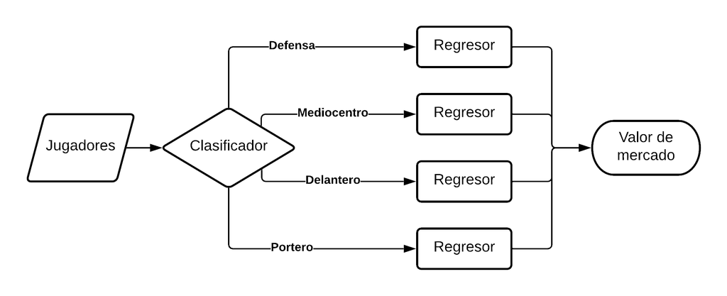

fifa pipeline

## 3.5 Habilidades extra

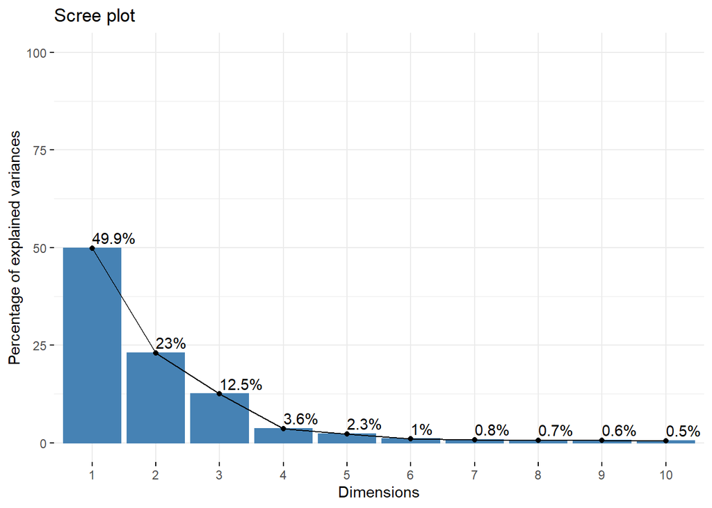

```r
# Hacemos un PCA para seleccionar unas pocas variables de entre las 59 habilidades extra
pca.45_104 <- PCA(X = fifa[45:104], scale.unit = FALSE, graph = FALSE)
fviz_screeplot(pca.45_104, addlabels = TRUE, ylim = c(0, 100))
```

Observamos como de las 59 variables, hemos encontrado 3 que explican el 85.4% de la varianza. Esas tres componentes no son componentes existentes en el *dataset* sino que cada una es una combinación lineal de todas ellas. El método PCA nos ha permitido pasar de un espacio de 59 dimensiones a uno de 3, y únicamente estamos perdiendo un 14,6% de varianza.

Vamos a extraer la representación de cada instancia del *dataset* en base a esas tres variables:

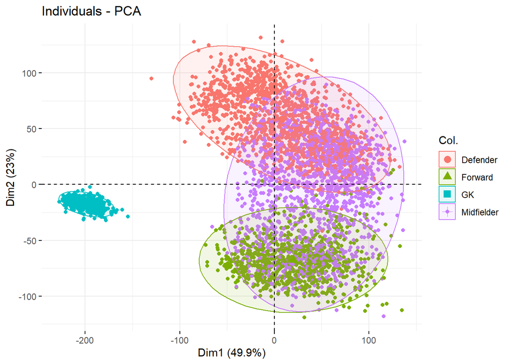

```r
# Representación de las observaciones con respecto a las dos primeras componentes con la posición.class
fviz_pca_ind(pca.45_104, geom.ind = "point",
             col.ind = fifa$player_positions.class,
             pch = 16,
             addEllipses=TRUE, ellipse.level=0.95,
             axes = c(1, 2),
             pointsize = 1.5)
```

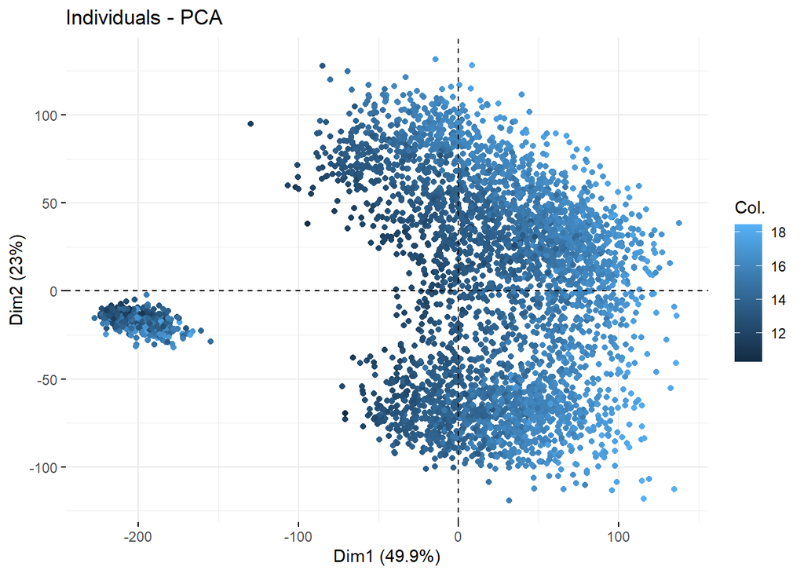

```r
# Representación de las observaciones con respecto a las dos primeras componentes con el logaritmo del valor
fviz_pca_ind(pca.45_104, geom.ind = "point",
             col.ind = fifa$value_eur.log,
             palette = "viridis",
             pch = 16,
             axes = c(1, 2),
             pointsize = 1.5)
```

Se observa un cierto gradiente de color que inidica que quizás pueda existir correlación entre estas componentes y el valor (en escala logarítmica).

```r
my.head(pca.45_104$ind$coord[,1:3])
```

| Dim.1 | Dim.2 | Dim.3 |
| --- | --- | --- |
| -31.869427 | 74.68304 | -17.05656 |
| 5.989421 | -71.28505 | -33.78433 |
| -40.268580 | 42.59844 | -59.96463 |
| -35.050179 | -72.23773 | -64.24624 |
| -10.178259 | -69.90865 | -54.19208 |
| -57.275347 | -39.67877 | -85.76152 |

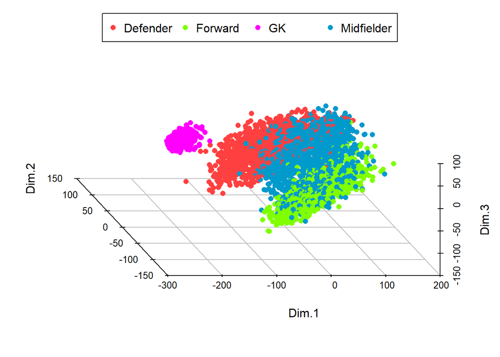

```r
# Representación gráfica en 3 dimensiones de las tres primeras componentes junto con la posición.class
#install.packages("scatterplot3d") # Install
#library("scatterplot3d") # load
colors <- c("brown1", "chartreuse", "magenta", "deepskyblue3")
colors <- colors[as.factor(fifa$player_positions.class)]
scatterplot3d(pca.45_104$ind$coord[,1:3], angle = 115, pch = 16, color= colors, box = FALSE)
legend("top", legend = levels(as.factor(fifa$player_positions.class)),
      col = c("brown1", "chartreuse", "magenta", "deepskyblue3"), pch = 16, bg = "transparent",
      inset = -0.2, xpd = TRUE, horiz = TRUE)
```

Observamos como las cuatro posiciones fundamentales constituyen cada una un *clúster* en el gráfico. Es por ello que se prevee que las tres primeras componentes extraídas del PCA sean buenos clasificadores. Para poder usarlos en los modelos posteriores, vamos a añadirlas al dataset:

```r
fifa$PC1 <- pca.45_104$ind$coord[,1]
fifa$PC2 <- pca.45_104$ind$coord[,2]
fifa$PC3 <- pca.45_104$ind$coord[,3]
```

Ahora se encuentran al final del *dataset*.

# 4 Modelos de regresión

```r
# Seleccionamos el juego de datos
#fifa.mod <- fifa.def
#fifa.mod <- fifa.mid
#fifa.mod <- fifa.for
fifa.mod <- fifa

#fifa.mod$value_eur <- fifa.mod$value_eur #/ 1000000

## set the seed to make your partition reproducible
set.seed(123)
test_ind <- sample(seq_len(nrow(fifa.mod)), size = floor(0.25 * nrow(fifa.mod)))
fifa.mod.Train <- fifa.mod[-test_ind, ]
fifa.mod.Test <- fifa.mod[test_ind, ]

fifa.mod.Train.def <- fifa.mod.Train %>% filter(player_positions.class == "Defender")
fifa.mod.Train.mid <- fifa.mod.Train %>% filter(player_positions.class == "Midfielder")
fifa.mod.Train.for <- fifa.mod.Train %>% filter(player_positions.class == "Forward")

fifa.mod.Test.def <- fifa.mod.Test %>% filter(player_positions.class == "Defender")
fifa.mod.Test.mid <- fifa.mod.Test %>% filter(player_positions.class == "Midfielder")
fifa.mod.Test.for <- fifa.mod.Test %>% filter(player_positions.class == "Forward")


# Defender
mod_Defender_1 <- lm(value_eur.log ~ overall    + potential + defending + PC1 + PC2 + PC3, data = fifa.mod.Train.def)
#mod_Defender_2 <- lm(value_eur.log ~ overall   + potential + defending + physic, data = fifa.mod.Train.def)
# Midfielder
mod_Midfielder_1 <- lm(value_eur.log ~ overall  + potential + passing   + dribbling + shooting + PC1 + PC2 + PC3, data = fifa.mod.Train.mid)
#mod_Midfielder_2 <- lm(value_eur.log ~ overall + potential + passing   + dribbling, data = fifa.mod.Train.mid)
#mod_Midfielder_3 <- lm(value_eur.log ~ overall + potential + passing, data = fifa.mod.Train.mid)
# Forward
mod_Forward_1 <- lm(value_eur.log ~ overall + potential+ shooting + dribbling + PC1 + PC2 + PC3, data = fifa.mod.Train.for)
#mod_Forward_2 <- lm(value_eur.log ~ overall    + potential+ shooting, data = fifa.mod.Train.for)
#mod_Forward_3 <- lm(value_eur.log ~ overall    + potential+ dribbling, data = fifa.mod.Train.for)


# Tabla con los coeficientes de determinación de cada modelo
tabla.coeficientes <- matrix(c('mod_Defender_1',   summary(mod_Defender_1)$r.squared,sqrt(deviance(mod_Defender_1)/df.residual(mod_Defender_1)),
                               'mod_Midfielder_1', summary(mod_Midfielder_1)$r.squared,sqrt(deviance(mod_Midfielder_1)/df.residual(mod_Midfielder_1)),
                               'mod_Forward_1',    summary(mod_Forward_1)$r.squared,sqrt(deviance(mod_Forward_1)/df.residual(mod_Forward_1))),ncol = 3, byrow = TRUE)
colnames(tabla.coeficientes) <- c("Modelo", "R^2", "Residual standard error")
tabla.coeficientes
```

```
##      Modelo             R^2                 Residual standard error
## [1,] "mod_Defender_1"   "0.959521405900756" "0.267969075140707"
## [2,] "mod_Midfielder_1" "0.973903850908824" "0.228286795895886"
## [3,] "mod_Forward_1"    "0.971127473142748" "0.242401578600199"
```

```r
# Creamos las predicciones para los modelos
pred_Defender_1 <- predict(mod_Defender_1, fifa.mod.Test)
pred_Midfielder_1 <- predict(mod_Midfielder_1, fifa.mod.Test)
pred_Forward_1 <- predict(mod_Forward_1, fifa.mod.Test)

# Mostramos los resultados
df <- data.frame(Pos=fifa.mod.Test$player_positions.class, Original=fifa.mod.Test$value_eur.log,
                 pred_Defender_1=pred_Defender_1,
                 pred_Midfielder_1=pred_Midfielder_1,
                 pred_Forward_1=pred_Forward_1)
my.kable(df)
```

|  | Pos | Original | pred_Defender_1 | pred_Midfielder_1 | pred_Forward_1 |
| --- | --- | --- | --- | --- | --- |
| 2463 | Midfielder | 13.56062 | 13.72828 | 13.85034 | 13.86139 |
| 2511 | Defender | 15.95558 | 15.93569 | 16.06200 | 16.11150 |
| 2227 | Defender | 16.67771 | 16.72547 | 16.78735 | 16.81965 |
| 526 | Midfielder | 13.01700 | 13.09615 | 12.96283 | 12.96580 |
| 2986 | Midfielder | 14.34614 | 14.72540 | 14.57210 | 14.60960 |
| 1842 | Defender | 12.10071 | 11.99015 | 12.06317 | 12.26154 |
| 1142 | Midfielder | 13.73755 | 13.85626 | 13.82247 | 13.79795 |
| 3371 | Forward | 15.29712 | 15.66443 | 15.14897 | 15.12666 |
| 3446 | Midfielder | 13.68198 | 14.00953 | 13.79891 | 13.80166 |
| 1627 | Midfielder | 15.34157 | 15.68383 | 15.27299 | 15.23753 |
| 2757 | Defender | 13.30468 | 13.23680 | 13.11853 | 13.30650 |
| 953 | Midfielder | 14.15198 | 14.42359 | 14.48039 | 14.45092 |
| 1017 | Defender | 13.42247 | 13.46697 | 13.20514 | 13.57980 |
| 2013 | Midfielder | 13.81551 | 14.30665 | 13.95421 | 13.93365 |
| 2888 | Midfielder | 13.38473 | 13.44508 | 13.32938 | 13.36351 |
| 2567 | Defender | 13.52783 | 13.55599 | 13.39523 | 13.65953 |
| 1450 | Defender | 13.07107 | 13.08368 | 13.07529 | 13.17598 |
| 1790 | Midfielder | 15.83041 | 15.77776 | 15.67223 | 15.66826 |
| 2980 | Midfielder | 16.48966 | 16.88606 | 16.50727 | 16.47925 |
| 1614 | GK | 12.30138 | NA | NA | NA |
| 555 | Forward | 15.76142 | 15.85535 | 15.45493 | 15.49196 |
| 1167 | Midfielder | 13.45884 | 13.56975 | 13.49824 | 13.49804 |
| 2592 | Midfielder | 14.55745 | 14.43140 | 14.46276 | 14.44033 |
| 2538 | Defender | 15.76142 | 15.71891 | 15.85400 | 15.91037 |
| 1799 | Forward | 16.11810 | 16.74546 | 16.36119 | 16.34398 |
| 905 | GK | 17.24950 | NA | NA | NA |
| 1047 | Midfielder | 15.68731 | 15.52326 | 15.67435 | 15.67499 |
| 3004 | Midfielder | 16.34124 | 16.10240 | 16.25128 | 16.23550 |
| 3207 | Midfielder | 15.03929 | 14.87530 | 15.00982 | 15.00560 |
| 3995 | Forward | 13.52783 | 13.86390 | 13.75145 | 13.73427 |

[output cut: 1011 more lines]

```r
res <- data.frame(df$Original,
                 df$Original-df$pred_Defender_1,
                 df$Original-df$pred_Midfielder_1,
                 df$Original-df$pred_Forward_1)
colnames(res) <- c("Original", "Residuo Def", "Residuo Mid", "Residuo For")
my.head(res)
```

| Original | Residuo Def | Residuo Mid | Residuo For |
| --- | --- | --- | --- |
| 13.56062 | -0.1676650 | -0.2897234 | -0.3007724 |
| 15.95558 | 0.0198861 | -0.1064195 | -0.1559231 |
| 16.67771 | -0.0477579 | -0.1096388 | -0.1419369 |
| 13.01700 | -0.0791440 | 0.0541700 | 0.0512075 |
| 14.34614 | -0.3792587 | -0.2259660 | -0.2634622 |
| 12.10071 | 0.1105657 | 0.0375410 | -0.1608297 |

Una cuestión importante acerca de los residuos de la regresión. La idea es deterctar jugadores con un precio inferior al que predice el modelo. La diferencia entre el valor real y el valor predicho es el residuo de la medida. Pero al tener una regresión con la variable a predecir en escala logarítmica hay que deshacerla para poder extraer las conclusiones. Si llamamos $y$ a a variable que queremos predecir, en este caso `value_eur`:

$$\mbox{residuo}=log(y_{obs})-log(y_{pred})=log(\frac{y_{obs}}{y_{pred}})\Rightarrow e^{\mbox{residuo}}=e^{log(y_{obs})-log(y_{pred})}=e^{log(\frac{y_{obs}}{y_{pred}})}=\frac{y_{obs}}{y_{pred}}\Rightarrow \\ \Rightarrow e^{\mbox{residuo}}=\frac{y_{obs}}{y_{pred}}$$

Por tanto, deebmos calcular la exponencial de los residuos de la regresión. Esa columna será el cociente entre el valor observado y el predicho. Si, por ejemplo, buscamos jugadores cuyo valor de mercado sea un 10% inferior a su valor predicho, debemos buscar los jugadores que cumplan:

$$\frac{y_{obs}}{y_{pred}}<0.90 \Rightarrow e^{\mbox{residuo}}<0.90 \Rightarrow \mbox{residuo}<log(0.90)=-0.105$$

```r
fifa.mod <- fifa

fifa.mod$value_eur <- fifa.mod$value_eur / 1000000

## set the seed to make your partition reproducible
set.seed(123)
test_ind <- sample(seq_len(nrow(fifa.mod)), size = floor(0.25 * nrow(fifa.mod)))
fifa.mod.Train <- fifa.mod[-test_ind, ]
fifa.mod.Test <- fifa.mod[test_ind, ]


mod_overall <- lm(overall ~ age + value_eur + potential + wage_eur, data = fifa.mod.Train)


# Tabla con los coeficientes de determinación de cada modelo
tabla.coeficientes <- matrix(c('mod_overall', summary(mod_overall)$r.squared,sqrt(deviance(mod_overall)/df.residual(mod_overall))
                            ),ncol = 3, byrow = TRUE)
colnames(tabla.coeficientes) <- c("Modelo", "R^2", "Residual standard error")
tabla.coeficientes
```

```
##      Modelo        R^2                 Residual standard error
## [1,] "mod_overall" "0.887380437066079" "2.38976687445762"
```

```r
# Creamos las predicciones para los modelos
pred_mod_overall <- predict(mod_overall, fifa.mod.Test)

# Mostramos los resultados
df <- data.frame(Original=fifa.mod.Test$overall,
                 pred_mod_overall=pred_mod_overall)
my.head(df)
```

|  | Original | pred_mod_overall |
| --- | --- | --- |
| 2463 | 68 | 69.53766 |
| 2511 | 78 | 76.47067 |
| 2227 | 80 | 78.10838 |
| 526 | 61 | 62.68719 |
| 2986 | 69 | 68.32838 |
| 1842 | 58 | 58.10047 |

# 5 Predicción por posición

## 5.1 Seleccionamos los objetivos

```r
# Creamos dos funciones para analizar los métodos
normalize <- function(x) { ((x - min(x)) / (max(x) - min(x))) }
accuracy  <- function(x) { sum(diag(x)/(sum(rowSums(x)))) * 100 }

# Escogemos el Objetivo
y = factor(fifa$player_positions.class)

# Escogemos una semilla y dividimos en Train y Test
set.seed(123)
test_ind <- sample(seq_len(nrow(fifa)), size = floor(0.25 * nrow(fifa)))

# Separamos el objetivo en Train y Test
y.Train <- y[-test_ind]
y.Test  <- y[test_ind]
```

## 5.2 Seleccionamos las variables de entrada

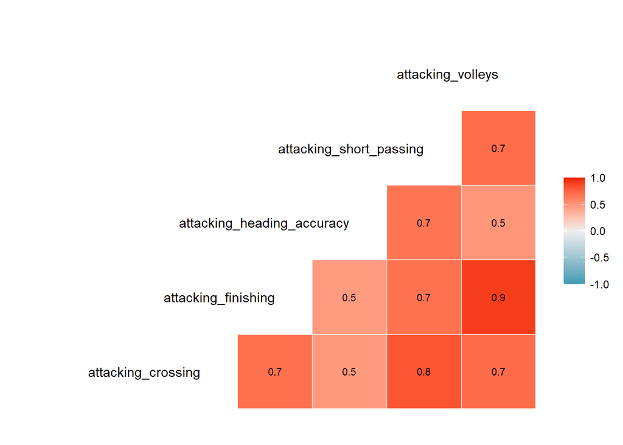

```r
X <- fifa[45:104]

ggcorr(X[1:5], label = TRUE, label_size = 2.9, hjust = 1, layout.exp = 2)
```

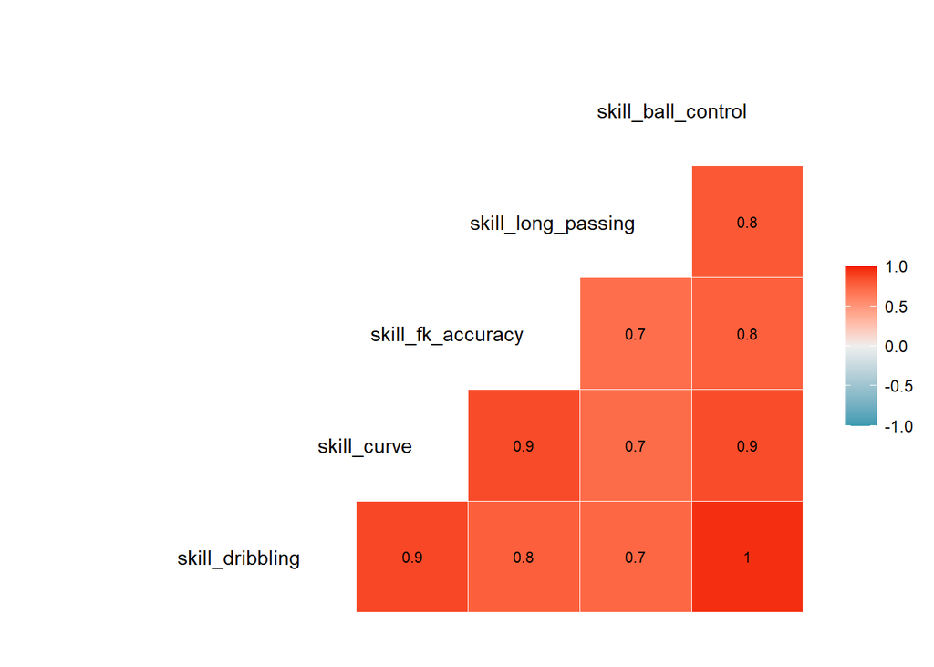

```r
ggcorr(X[6:10], label = TRUE, label_size = 2.9, hjust = 1, layout.exp = 2)
```

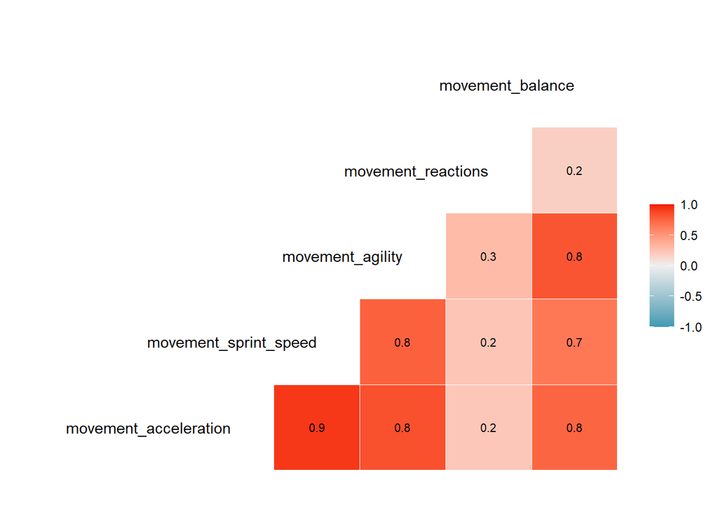

```r
ggcorr(X[11:15], label = TRUE, label_size = 2.9, hjust = 1, layout.exp = 2)
```

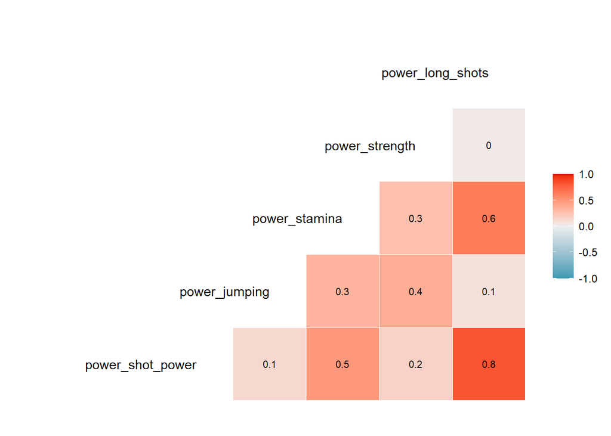

```r
ggcorr(X[16:20], label = TRUE, label_size = 2.9, hjust = 1, layout.exp = 2)
```

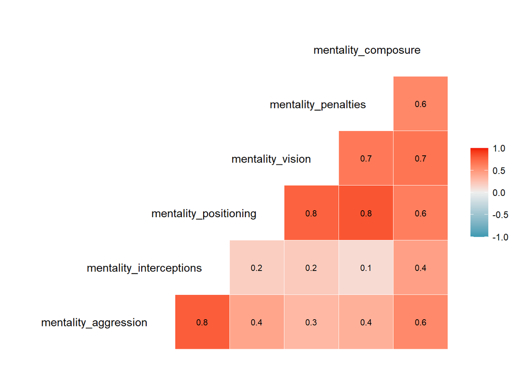

```r
ggcorr(X[21:26], label = TRUE, label_size = 2.9, hjust = 1, layout.exp = 2)
```

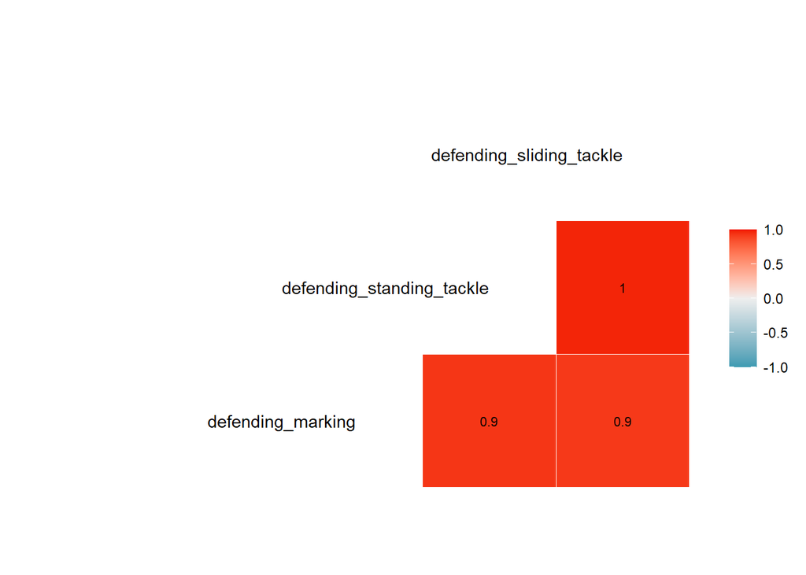

```r
ggcorr(X[27:29], label = TRUE, label_size = 2.9, hjust = 1, layout.exp = 2)
```

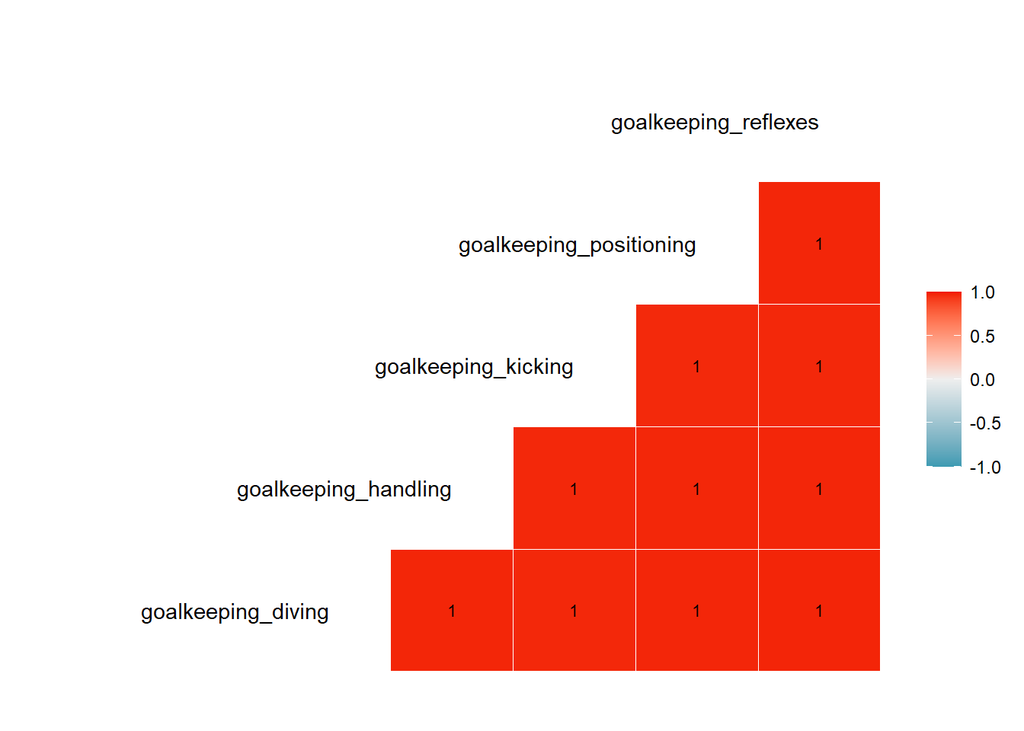

```r
ggcorr(X[30:34], label = TRUE, label_size = 2.9, hjust = 1, layout.exp = 2)
```